# Geographical variation in ant foraging activity and resource use is driven by climate and net primary productivity - Lasmar - - Journal of Biogeography - Wiley Online Library

[Journal of Biogeography](https://onlinelibrary.wiley.com/journal/13652699)

[Early View](https://onlinelibrary.wiley.com/toc/13652699/0/0)

[figure not shown]

RESEARCH ARTICLE

Full Access

# Geographical variation in ant foraging activity and resource use is driven by climate and net primary productivity

[Chaim J. Lasmar](https://onlinelibrary.wiley.com/action/doSearch?ContribAuthorStored=Lasmar%2C+Chaim+J)

[Tom R. Bishop](https://onlinelibrary.wiley.com/action/doSearch?ContribAuthorStored=Bishop%2C+Tom+R)

[Catherine L. Parr](https://onlinelibrary.wiley.com/action/doSearch?ContribAuthorStored=Parr%2C+Catherine+L)

[Antônio C. M. Queiroz](https://onlinelibrary.wiley.com/action/doSearch?ContribAuthorStored=Queiroz%2C+Ant%C3%B4nio+C+M)

[Fernando A. Schmidt](https://onlinelibrary.wiley.com/action/doSearch?ContribAuthorStored=Schmidt%2C+Fernando+A)

[Carla R. Ribas](https://onlinelibrary.wiley.com/action/doSearch?ContribAuthorStored=Ribas%2C+Carla+R)

First published: 28 March 2021

https://doi.org/10.1111/jbi.14089

## Abstract

### Aim

Foraging activity is critical for animal survival. Comprehending how ecological drivers influence foraging behaviour would benefit our understanding of the link between animals and ecological processes. Here, we evaluated the influence of ecological drivers on ant foraging activity and relative resource use.

### Location

Six Brazilian biomes: Amazon, Atlantic rainforest, Caatinga, Cerrado, Pampa and Pantanal.

### Taxon

Formicidae.

### Methods

We assessed ant foraging activity and resource use by sampling across 60 sites. We placed baited tubes that contained one of five liquid resources (sugar, lipids, amino acid, sodium and distilled water). We used model selection to assess the influence of ecological drivers (temperature, precipitation, temperature seasonality and net primary productivity) on ant foraging activity and relative resource use.

### Main conclusions

We demonstrate how ecological drivers are correlated with ant foraging activity and resource use in the field across large spatial scales. The search for resources encompasses different interactions involving ants with abiotic and biotic components in the ecosystem. Thus, we suggest that changes in climate and NPP, which influence the intensity and the way that ants search for resources, will result in changes in ant‐mediated ecological processes.

## 1 INTRODUCTION

Foraging is critical for animal fitness (Raubenheimer et al. 2009; Smith, 1978). Through foraging for resources, animals are integrated into the diversity of ecological interactions and nutrient cycles that make up functioning ecosystems (Folgarait, 1998; Tilman et al. 2014). Foraging activity varies substantially across space and time; for example, arthropod foraging activity is generally higher in the tropics than in the temperate zone, higher at low elevations compared with high elevations (Peters et al., 2014; Roslin et al., 2017) and changes seasonally (Wolda, 1978). Given that foraging behaviour influences numerous ecosystem processes (e.g. nutrient cycling, decomposition; Maisey et al., 2020), identifying which drivers limit or promote foraging activity and resource use will help us understand ecosystem functioning in a rapidly changing world.

Animal foraging activity is influenced by four main ecological drivers which are related to ecosystem energy input and the prevailing climate. (1) Net primary productivity (NPP) is the fuel for all animals and is often positively correlated with foraging activity (lizards: Buckley et al., 2008; birds: Meehan et al., 2004; and arthropods: Kaspari & de Beurs, 2019). (2) Temperature has a substantial impact on biochemical reaction rates and animal metabolism (Brown, 2014). Consequently, at higher temperatures, animals tend to be more active, move faster and are, up to a point, more likely to find resources while foraging (Stuble et al. 2013). (3) Overall annual precipitation may lead to increased foraging activity due to reduced desiccation risk and increased plant resource availability (Costa et al., 2018; Kaspari & Weiser, 2000). Actual precipitation events may, however, also reduce foraging activity (particularly for small invertebrates) due to the difficulty of foraging in the rain (Poulsen, 2008). (4) Seasonality in both temperature and rainfall can influence the availability of resources through time (Belchior et al., 2016; Costa et al., 2018), and the physiology of living organisms – via the effects described previously. Both usually make the warm, rainy season that parts of the Neotropics experience better for foraging (Baudier et al., 2018; Wolda, 1988). Thus, we may expect that high seasonality affects foraging activity because, in highly seasonal environments, animals increase activity in favourable seasonal periods to compensate for their inability to forage in harsh seasonal periods (Kaspari et al., 2000). To date, there has not been an assessment of how all four of these ecological drivers work in concert to influence geographical variation in foraging activity.

Foraging activity may also change depending on the resource being foraged for, with resource demand or resource shortfall interacting with climate and NPP to drive resource use (Raubenheimer et al., 2009). Resource demand can be seen, for example, when the climate drives the demand for particular energy or nutrient sources. At higher temperatures, animals expend more effort collecting specific resources in order to compensate for the accelerated metabolic (e.g. sugar and sodium), excretion (e.g. sodium) and growth rates (e.g. amino acids) (Kutz et al., 2019; Prather et al., 2018). At low temperatures, on the other hand, there may be high levels of lipid consumption because of its thermal insulating properties (Heinze et al., 2003; Peters et al., 2014). In cases of resource shortfall, animals will dedicate a disproportionately high foraging effort to collect resources that are in deficit in the environment (Kaspari, 2020; Kaspari et al., 2008). For example, at low levels of NPP, animals bias their foraging effort towards collecting high‐energy sugar (Kaspari et al., 2020). Similarly, as precipitation events are positively linked to plant resource availability (Costa et al., 2018), we may also expect greater foraging effort for high‐energy resources in drier regions. In environments with high climatic seasonality, there may be significant foraging effort put in towards collecting lipids, as they are easier to store for use in harsh periods (Heinze et al., 2003). In sum, resource use can vary geographically according to shortfall and demand, which may in turn be influenced by climate and NPP (Kaspari et al., 2020).

Despite the potential influence of NPP and climate drivers on foraging behaviour, most studies of foraging activity patterns and resource use have focused mainly on the effects of temperature and net primary productivity (e.g. Kaspari & de Beurs, 2019). Furthermore, most have not directly assessed foraging activity but have instead used indirect measurements such as counting the number of individuals in a trap and bite marks in artificial plasticine animals (e.g. Gibb et al., 2019; Kaspari & de Beurs, 2019, but see Kaspari et al. 2020; Sheard et al. 2020).

Ants are an excellent model taxon for studying the variation in foraging activity and resource use because they are some of the most abundant living animals. Through their foraging activities, ants are essential components of terrestrial ecosystems as seed dispersers, granivores, scavengers, predators and for cycling of nutrients (Blüthgen & Feldhaar, 2010; Folgarait, 1998; Griffiths et al. 2018). Ants require a range of different macro‐ and micronutrients for their development, and they must interact in different ways with plants, other animals and with the environment to obtain resources (Blüthgen & Feldhaar, 2010). Sugar and lipids are the main sources of energy for the entire colony, while lipids and amino acids are important for colony growth and development of larvae (Csata & Dussutour, 2019). Sodium is important for several physiological and metabolic processes (Csata & Dussutour, 2019). Hence, the foraging behaviour of ants provides a model system to investigate how climate and NPP interact to influence geographical variation in foraging activity and resource use.

Given that ants play an important role in numerous ecosystem processes, understanding the influence of ecological drivers that potentially drive their foraging activity and their differential resource use will allow us to assess how changes in climate and NPP could affect future ant‐mediated ecosystem function. Here, we assessed ant foraging activity and relative resource use across six biomes in Brazil which vary in their climate and NPP. Specifically, we predict that: (i) ant foraging activity will respond positively to temperature, precipitation, NPP and climate seasonality; (ii) temperature will positively affect the relative use of sugar, amino acid and sodium, and negatively affect the relative lipid use; (iii) low precipitation and NPP will increase the relative use of high‐energy resources (sugar and lipids) and (iv) climatic seasonality will increase the relative use of lipids.

## 2 MATERIAL AND METHODS

### 2.1 Study area

We sampled in protected areas across six different biomes in Brazil which have different climates and vegetation types (Figure 1; Table 1). We carried out sampling in the rainy season of each biome (i.e. usually when foraging activity is highest) between November 2016 and March 2018.

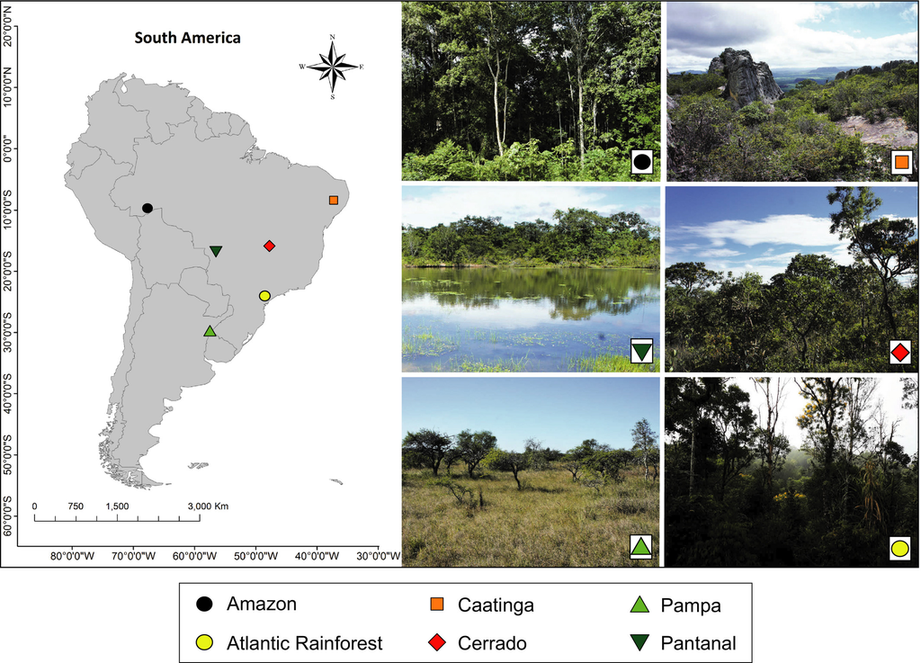

**FIGURE 1**

Location of the ant sampling sites across six Brazilian biomes

TABLE 1. Sampling sites characterization. Vegetation types of the sampled areas across six Brazilian biomes. Climate data were obtained from WorldClim Version 2 (Fick and Hijmans, 2017) just from one geographical point to represent each biome

| Biome and location | Vegetation type | Annual mean temperature (°C) | Annual minimum mean temperature (°C) | Annual maximum mean temperature (°C) | Annual precipitation (mm) | Precipitation of the driest month (mm) | Precipitation of the wettest month (mm) | Altitude (average) (m.a.s.l) | Sampling period |
| --- | --- | --- | --- | --- | --- | --- | --- | --- | --- |
| Amazon Reserva Florestal de Humaitá (9°46′13″S, 67°37′7″W). | Open rainforest with palm trees and bamboo | 25.2 | 17.8 | 31.5 | 1,720 | 46 | 233 | 185 | Nov/2016 |
| Atlantic rainforest Parque Estadual Intervales (24°17′13″S, 48°26′41″W). | Montane dense rainforest | 17.7 | 8.5 | 26.6 | 1,419 | 50 | 207 | 800 | Mar/2018 |
| Caatinga Parque Nacional do Catimbau (8°30′19″S, 37°18′37.86″W). | Shrublands | 20.5 | 13.9 | 29 | 721 | 17 | 128 | 970 | Jul/2017 |
| Cerrado Reserva Ecológica do IBGE and Jardim Botânico de Brasília (15°55′33″S, 47°52′59″W). | Brazilian savannah; Cerrado *strictu senso* | 20.1 | 11.5 | 27.5 | 1,519 | 8 | 263 | 1,100 | Dec/2017 |
| Pampa Parque Estadual do Espinilho (30°11′25″S, 57°29′51″W). | Humid steppe savannah | 19.8 | 7.7 | 31.2 | 1,474 | 67 | 165 | 51 | Nov/2017 |
| Pantanal Sesc Pantanal (16°31′22.59″S, 56°24′6.41″W). | Mixed vegetation: from grasslands and natural forest remnants, also natural floods | 25.2 | 14.9 | 34.9 | 1,317 | 19 | 215 | 123 | Apr/2017 |

### 2.2 Sampling of foraging ants

For all biomes, baiting was restricted to sunny periods, and never in rain or on totally cloudy days. We began placement of the baited tubes at 7:00 am at each site for all biomes except in the sites of Caatinga biome, where we delayed placement until 1:00 pm because light rainfall during the morning may have reduced ant activity in this period. By restricting the sampling to one period (mornings or afternoon) in each study area, we avoided large variation in temperature. We left all tubes open for 3 hours, after which we capped the tubes to collect the ants inside. A tube was classed as visited when there was at least one ant individual inside.

In the laboratory, we counted all ant workers and identified them to genera following Baccaro et al. (2015) and where possible, to species level or morphospecies by matching them with the ant reference collection of Laboratório de Ecologia de Formigas of the Universidade Federal de Lavras (UFLA). After that, we confirmed the identification at Laboratório de Sistemática de Formigas of the Universidade Federal do Paraná (UFPR). Voucher specimens were deposited in the reference collection of Laboratório de Ecologia de Formigas at UFLA and the Entomological Collection Padre Jesus Santiago Moure of UFPR (DZUP).

We considered the proportional occurrence of foraging ants (the overall proportion of visited tubes per transect across all ants, irrespective of species identity) as a proxy of ant foraging activity. Relative resource use was then calculated as the number of visited tubes of a given resource, divided by the total number of visited tubes (including control tubes) per transect. Consequently, relative resource use indicates the use of a given resource type in relation to all others and is not dependent on the different occurrences of foraging ants in transects, whereby a relative use of 1 indicates that all foraging was focused on a given resource, whereas a relative use of 0 means than no foraging took place on that resource.

### 2.3 Ecological drivers

Data for climate and NPP were obtained for 60 1‐km<sup>2</sup> grid cells, which each contained one sampled transect. We obtained data for temperature, precipitation and climate seasonality from the WorldClim 2 database (Fick & Hijmans, 2017), which represents average climate between 1970 and 2000. For each transect, we extracted the WorldClim variables mean annual temperature (°C), annual precipitation (mm), temperature seasonality (standard deviation of annual mean temperature) and precipitation seasonality (coefficient of variation of annual precipitation). For the months in which we sampled ants in each biome, we also extracted the data for monthly mean temperature (°C) and monthly precipitation (mm; Table 1). We obtained net primary productivity (NPP) from MODIS, using annual NPP from 2000 to 2015 (MOD17) from the NASA Earth Observation System repository at the University of Montana (www.ntsg.umt.edu/), which has been improved by correcting for cloud‐contaminated pixels and uses a model that considers the difference between gross primary productivity and autotrophic respiration (Zhao & Running, 2010).

We compared the WordClim estimates of climate to nearest climatic station (NCS) weather data from 1970 to the present (See Appendix S1). We did this to check whether (1) our sampling periods experienced extreme weather compared to the historical average and, (2) to assess whether WorldClim reliably predicted NCS estimates of local conditions. The NCS data showed that the time periods in which we sampled were not extreme relative to the historical record (Figure S1.1 in Appendix S1), and that the WorldClim data closely matched the estimates of temperature and rainfall for all sites (Figure S1.2 in Appendix S1). Consequently, we opt to use WorldClim data in our analyses as a good representation of both local weather during sampling and long‐term climatic trends and because WorldClim provides better spatial cover of the sampling sites.

### 2.4 Data analyses

Before analysing the data, we checked for collinearity between our climate and productivity drivers (‘Psych’ package (Revelle, 2011) in R version 3.4.1 (R Development Core Team, 2017). We found strong associations (correlation R > 0.65) between annual mean and monthly mean temperatures, annual and monthly precipitation as well as between temperature seasonality and precipitation seasonality (see Figure S1.3 in Appendix S1). Consequently, we performed all subsequent analyses with monthly mean temperature, monthly precipitation, temperature seasonality and NPP to represent the ecological drivers of temperature, precipitation, seasonality and NPP. As temperature and precipitation may vary substantially across the year, using mean monthly values is a more accurate way to represent the climate in our sampling periods. In addition, we chose temperature seasonality instead of precipitation seasonality because ant metabolism is expected to be directly affected by temperature (Gillooly et al., 2001). Proportional foraging activity and relative resource use data were logit‐transformed to meet Gaussian assumptions (Warton & Hui, 2011).

All analyses were carried out using proportional values per transect of ant foraging activity and relative resource use as response variables (*n* = 60). To assess the influence of ecological drivers on the ant foraging activity, we constructed generalized linear mixed models (GLMM) with logit‐transformed proportional occurrence of foraging ants as the response variable and temperature, precipitation, temperature seasonality and NPP as explanatory variables (fixed effects). Biome was assigned as the random effect to account for the possibly spatial autocorrelation between transects in the same biome. We used the *dredge* function (‘MuMIn’ package version 1.10.5; Barton, 2014) to run all possible models, ranking them based on the Akaike information criterion corrected (AICc) and considering only the models with ΔAICc < 2 (Burnham & Anderson, 2002). We ran the modelling process with and without the data for control tubes. Because results from the two sets of modelling procedures did not differ, there was no evidence that control tubes affected the foraging patterns found (Appendix S2; Table S2.2). Therefore, we only report results without control tubes. We searched for potential “uninformative parameters” within the models where ΔAICc < 2 by following the approach proposed by Leroux (2019). Leroux’s (2019) approach involves two steps. First, we compared the log‐likelihoods of the top model and those models within ΔAICc < 2 that had additional parameters not in the top model. If the log likelihoods were different, we considered the additional parameters as informative. If the log likelihoods were similar, we checked to see if the 95% confidence intervals of the additional parameters overlapped zero. If the confidence intervals overlapped zero, we considered the parameters to be uninformative, if they did not overlap zero, we considered them to be informative.

Since foraging activity can be related to species richness and abundance (Gibb et al., 2019; Kaspari et al., 2000), we also ran a GLM to assess whether the foraging activity was correlated with the number of ant workers or species richness for each transect. Where a significant correlation was detected, we extracted the model residuals (as the response variable) and performed another model selection using the *dredge* function to determine how the foraging activity was influenced by ecological drivers, while controlling for these correlations.

To assess how ecological drivers influence relative resource use, we performed the same model selection of GLMMs using the *dredge* function, modelling each relative resource use (control, sugar, lipids, amino acids and sodium) as the response variable and including temperature, precipitation, temperature seasonality and NPP as explanatory variables (fixed effects) and the biome as random effect. We also looked for uninformative parameters in the models with ΔAICc < 2 as proposed by Leroux (2019). Furthermore, as the availability of water in the sugar, amino acids and sodium solutions could influence their use as resources, we performed another model selection that included the relative use of the control tubes (distilled water) as an extra explanatory variable. We expected that, if ants visited those resources because they were attracted to the water, then the relative use of the controls alone would explain most of the variation in resource use.

## 3 RESULTS

### 3.1 How do ecological drivers influence ant foraging activity?

We sampled 16,065 ant workers belonging to 188 ant species and 30 genera across all transects (Table S2.4 in Appendix S2). The best models (ΔAICc < 2) explaining ant foraging activity included precipitation, temperature seasonality and NPP (Table 2). Thus, foraging activity increased with increasing precipitation and NPP, and decreased with temperature seasonality (Figure 2).

TABLE 2. Model selection using the *dredge* function (Barton, 2015) based on the Akaike information criterion corrected (AICc) ranking of ecological drivers influence on ant foraging activity and resource use (n = 60) across six Brazilian biomes. The generalized linear mixed models were constructed for question 1 and 2 with the explanatory variables: temperature (monthly mean temperature, MMTemp), precipitation (monthly precipitation, MPrec), temperature seasonality (TSeas), net primary productivity (NPP). Biome was the random variable. In question 1, we also performed the same model selection using the residuals from the correlation between ant foraging activity and ant species richness and using the residuals from the correlation between ant foraging activity and number of ant workers. In question 2, Models were run separately for four resource types represented as a solution of: 20% sugar (CHO, made with sucrose), lipids (extra virgin olive oil), 20% amino acids (AA, made with unflavored whey protein isolate), and 1% sodium (NaCl) and. We only considered and pointed out models equal or lower than ΔAICc = 2. Degrees of freedom of the model (d.f.), differences in AICc‐values (ΔAICc) and Akaike weight (ω) are shown. Marginal R<sup>2</sup> is the coefficient of determination of fixed effects (ecological drivers) and Conditional R<sup>2</sup> is the coefficient of determination of fixed effects plus random effects (biomes)

| Model | d.f. | AICc | ΔAICc | ω | Log Likelihood | Marginal R<sup>2</sup> | Conditional R<sup>2</sup> |
| --- | --- | --- | --- | --- | --- | --- | --- |
| Question 1: How do ecological drivers influence ant foraging activity? |  |  |  |  |  |  |  |
| MPrec | 4 | 121.3 | 0.00 | 0.16 | −56.31 | 0.19 | 0.82 |
| MPrec + TSeas | 5 | 121.8 | 0.43 | 0.13 | −55.32 | 0.38 | 0.82 |
| TSeas | 4 | 121.8 | 0.50 | 0.11 | −56.55 | 0.32 | 0.79 |
| TSeas + NPP | 5 | 122.5 | 1.15 | 0.10 | −55.69 | 0.32 | 0.79 |
| Null Model | 3 | 122.6 | 1.24 | 0.08 | −58.08 | ‐ | ‐ |
| Question 1: using the residuals from the correlation between ant foraging activity and ant species richness. |  |  |  |  |  |  |  |
| Null model | 3 | 126.0 | 0.00 | 0.30 | −59.80 | ‐ | ‐ |
| Question 1: using the residuals from the correlation between ant foraging activity and the number of ant workers. |  |  |  |  |  |  |  |
| MPrec + TSeas + NPP | 6 | 110.5 | 0.00 | 0.31 | −48.45 | 0.39 | 0.39 |
| TSeas + NPP | 4 | 110.8 | 0.30 | 0.27 | −49.83 | 0.36 | 0.36 |
| MMTemp + MPrec + TSeas + NPP | 7 | 111.6 | 1.14 | 0.18 | −47.73 | 0.41 | 0.41 |
| MMTemp + TSeas + NPP | 6 | 111.8 | 1.37 | 0.16 | −49.13 | 0.38 | 0.38 |
| Question 2: How do ecological drivers influence relative resource use of foraging ants? |  |  |  |  |  |  |  |
| CHO |  |  |  |  |  |  |  |
| MPrec +TSeas + NPP | 6 | 132.7 | 0.00 | 0.54 | −59.57 | 0.46 | 0.46 |
| MMTemp + MPrec + TSeas + NPP | 7 | 134.4 | 1.67 | 0.23 | −59.12 | 0.47 | 0.47 |
| Lipids |  |  |  |  |  |  |  |
| MMTemp + TSeas | 5 | 127.4 | 0.00 | 0.19 | −58.12 | 0.13 | 0.23 |
| MMTemp | 4 | 127.4 | 0.05 | 0.18 | −59.34 | 0.13 | 0.26 |
| MMTemp + MPrec + TSeas | 6 | 128.4 | 1.03 | 0.11 | −57.40 | 0.21 | 0.22 |
| Null Model | 3 | 128.6 | 1.27 | 0.09 | −61.09 | ‐ | ‐ |
| AA |  |  |  |  |  |  |  |
| MMTemp + TSeas + NPP | 6 | 173.6 | 0.00 | 0.39 | −79.98 | 0.32 | 0.32 |
| NaCl |  |  |  |  |  |  |  |
| MPrec + TSeas + NPP | 6 | 164.2 | 0.00 | 0.40 | −75.29 | 0.51 | 0.51 |
| MPrec + TSeas | 5 | 165.3 | 1.12 | 0.23 | −77.09 | 0.48 | 0.50 |
| MMTemp + MPrec + TSeas + NPP | 7 | 165.6 | 1.43 | 0.20 | −74.72 | 0.52 | 0.52 |

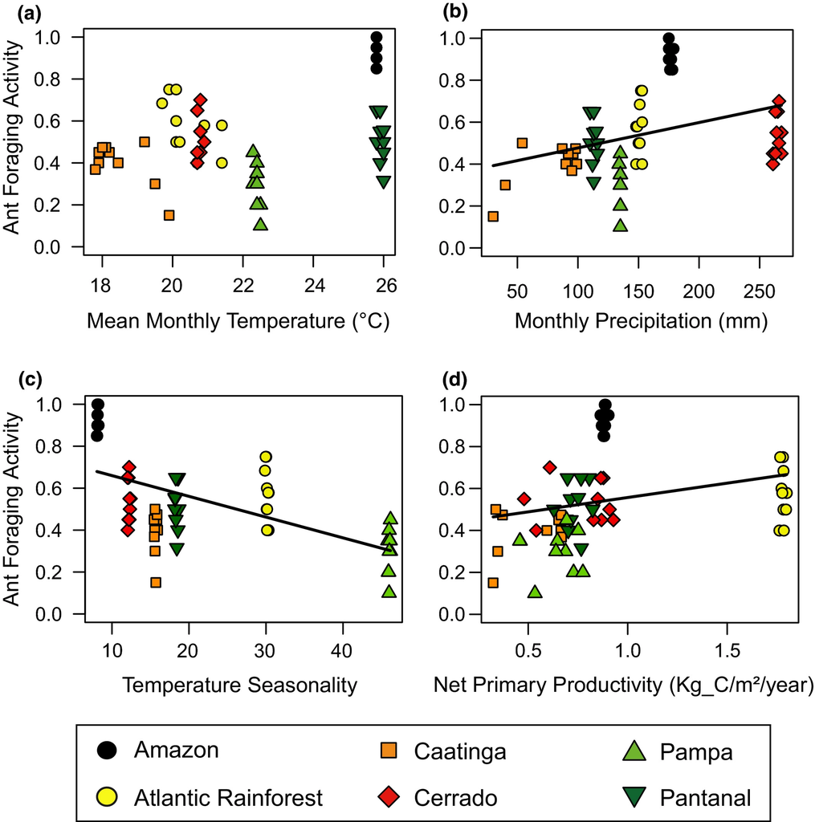

**FIGURE 2**

Relationship between ant foraging activity (measured by the proportional occurrence of foraging ants) and (a) mean monthly temperature; (b) monthly precipitation; (c) temperature seasonality and (d) net primary productivity (NPP) across 60 transects in six biomes in Brazil (*n* = 60). Points show the proportions of visited tubes per transect in each biome discriminated by specific symbols and colours and black lines represent significant relationships with ecological drivers. Lines are model predictions back transformed into the original variable scale based only on the fixed effects for best visualization

The proportion of visited tubes increased with both ant species richness and the number of ant workers (*R<sup>2</sup>* = 0.84; Figure S1.4 in Appendix S1). However, the model selection procedure using the residuals of the relationship between foraging activity and the number of ant workers retained the same explanatory variables as the original modelling plus temperature (Table 2). The model selection procedure using the residuals of the relationship between foraging activity and species richness did not retain any ecological drivers as explanatory variables (Table 2). This indicates that despite the fact that ant foraging activity is correlated with ant species richness and the number of ant workers, the influence of ecological drivers on foraging activity seems to be strongly linked to ant species richness but not with the number of ant workers.

### 3.2 How do ecological drivers influence relative resource use of foraging ants?

The most visited resource types were sugar and lipids, each with 34% of visited tubes over the whole study, followed by sodium with 17%, amino acids with 12% and distilled water with 3% (see full details in Table S2.3 in Appendix S2).

Almost all the best models (ΔAICc < 2) for each resource type included temperature, precipitation, temperature seasonality and NPP (Table 2). However, the influence of the climatic drivers and NPP on foraging differed strongly among resource types (Figure 3 and Figure S1.5–S1.8 in Appendix S1). Our results show that with increasing temperature, there was an increase in the relative use of amino acids, whereas the relative use of lipids decreased, but there was no influence of temperature on the relative use of sugar and sodium (Figure 3a). With increasing precipitation, there was an increase in the relative use of sodium and a decrease in the relative use of sugar and lipids. Amino acids remained unaffected by precipitation (Figure 3b). With greater temperature seasonality the relative use of sugar increased, while the relative use of lipids, amino acids and sodium decreased (Figure 3c). The influence of NPP on resource use also varied markedly among resource types: relative sugar use declined with increasing NPP, whereas the relative use of amino acids and sodium increased (Figure 3d). We identified possible uninformative parameters for the best models for relative use of sugar and sodium. We did not consider the effect of temperature on the relative use of sugar because temperature was present in the second‐best model and did not considerably improve the log likelihood in relation to the top model (log likelihood difference = 0.45; Table 2) and its estimate overlapped zero (CI 95% = −0.031, 0.090). We also did not consider the temperature effect on the relative use of sodium because temperature was present in the third‐best model, did not considerably improve the log likelihood in relation to the top model (log likelihood difference = 0.57; Table 2) and its estimate overlapped zero (CI 95% = −0.036, 0.121).

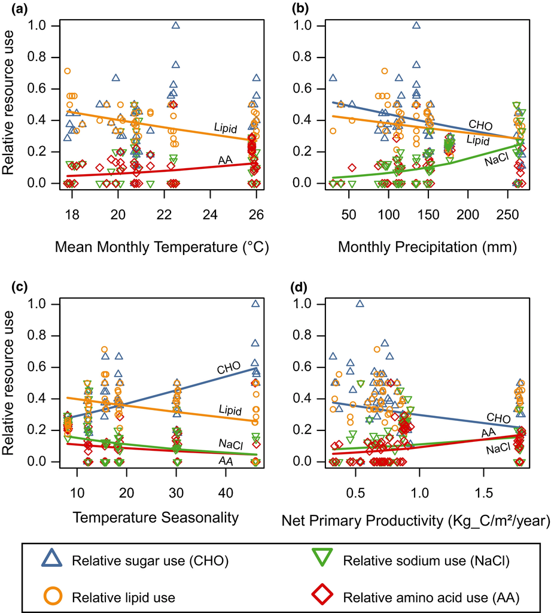

**FIGURE 3**

Relationship among relative use of sugar (CHO; Blue triangle), lipid (Orange circle), amino acid (AA; Red rhombus) and sodium (NaCl; Green upside‐down triangle) and (a) mean monthly temperature; (b) monthly precipitation; (c) temperature seasonality and (d) net primary productivity (NPP) across 60 transects in six biomes in Brazil (*n* = 60). Points show the relative use of each resource in the respective symbols and colours as well as lines, and the respective colours represent significant relationships with ecological drivers. Lines are model predictions back transformed into the original variable scale based only on the fixed effects for best visualization

No changes to the patterns of relative resource use were detected when the models were rerun including the relative use of controls as an explanatory variable (Table S2.2 in Appendix S2), indicating that ants visited the tubes containing sugar, amino acids and sodium solutions to forage for the resource, rather than for the water in the solutions.

## 4 DISCUSSION

Our study highlights the importance of ecological drivers for explaining geographical variation in ant foraging activity and resource use. Precipitation, temperature seasonality and NPP are related to the variation in ant foraging activity. This result, however, may partly be due to differences in species richness. Overall, ants preferred sugar and lipids across the six Brazilian biomes. This is consistent with previous studies in North America and Africa (e.g. Fowler et al., 2014; Peters et al., 2014) and indicates that high‐energy resources are the most sought after by ants. This may explain the high dominance behaviour of ants in protecting and monopolizing high‐energy resources in the wild (Grover et al., 2007), such as plant exudates and hemipteran honeydew. However, the novelty of our study is that geographical variation in four types of resources can be linked to climate and NPP.

### 4.1 How do ecological drivers influence ant foraging activity?

The influence of climate and NPP on foraging activity, however, appears to be linked to species richness. When we controlled for differences in ant species richness, we found no influence of any ecological driver. Previous long‐term studies have found that ant species richness is positively influenced by ant foraging activity (e.g. Gibb et al., 2019). This might indicate that the foraging activity of ants is intrinsically linked to their diversity patterns. Nevertheless, our observational study cannot determine whether foraging activity regulates species richness or vice versa, or whether ecological drivers independently influence both.

### 4.2 How do ecological drivers influence relative resource use of foraging ants?

We interpret the influences of precipitation, temperature seasonality and NPP on our relative resource use largely as a trade‐off between sugar on the one hand, and amino acids and sodium on the other. In drier and less productive environments with high‐temperature seasonality, the relative use of sugar increased, while the relative use of sodium and amino acids decreased (Figure 3b–d). Previous studies have demonstrated that low NPP, low precipitation and high climatic seasonality can limit how much energy ants can capture (Costa et al., 2018; Kaspari et al., 2020). This may explain the increase in the relative use of sugar in these environments (e.g. Caatinga and Pampa biomes, Table S2.3 in Appendix S2). Thus, we think that first ants try to address energy deficits by foraging more for sugar where the available energy is low. Then, when and where ants have sufficient levels of energy resources (e.g. in wetter and productive environments with low‐temperature seasonality) or where they are able to forage for longer periods throughout the year (e.g. environments with low‐temperature seasonality), ants increase the demand for amino acids that improve colony size (Asano & Cassill, 2012) and for sodium that support the high costs of foraging activity (Prather et al., 2018; Figure 3b–d). A similar trade‐off between sugar and protein has also been observed in studies at small spatial scales, where the resource preference of ants depends on availability of nectar from plants (e.g. Vidal et al., 2019). Yet, our findings are novel because the influence of precipitation, temperature seasonality and NPP on this trade‐off occurs at large spatial scales and this trade‐off not only involves the relationship between sugar and amino acids but also between sugar and sodium.

Precipitation and temperature seasonality also affected the relative use of lipids. However, we should interpret these results with caution. Lipids supply the energy demand for larval growth, while sugar supplies are needed for adult ants (Blüthgen & Feldhaar, 2010). As plant resource availability is influenced by precipitation (Costa et al., 2018), it is likely lipid resources are lower in drier environments. This may explain the same pattern for the relative use of sugar and lipids as they both increased in drier environments (Figure 3b). Besides supplying resources for larval growth, ants also access components in lipids that are important for egg production and ovary development, all related to the colony growth (Blüthgen & Feldhaar, 2010). Thus, following the same pattern as amino acids, it is possible that ants forage more for lipids in environments with low‐temperature seasonality (Figure 3c) to facilitate colony growth since energy demand has already been achieved. Considering that little is known about the diet requirements in ants of lipids (Csata & Dussutour, 2019), the influence of ecological drivers on the relative use of lipids appears complex. We should not assume the role of lipids for ants is not only to meet energy demands but also for colony growth.

Temperature likely influences relative resource use by acting on the physiology of ants. At small spatial scales, ants forage more for sugar and sodium to supply accelerated metabolic rates caused by temperature (Prather et al., 2018). However, we found no support for this since the influence of temperature on relative use of sugar and sodium in our study seemed to be an uninformative parameter in our models (sensu Leroux, 2019). On the other hand, at high temperatures the relative use of amino acids increased, probably to support accelerated colony growth, as suggested by theoretical studies (e.g. Asano & Cassill, 2012). By contrast, at low temperatures, ants increased the relative use of lipids probably because they are important components for thermal insulation (Heinze et al., 2003). Similar patterns have been found across elevational gradients (e.g. Peters et al., 2014). This probably indicates that the thermal insulation properties of lipids could be more important for the fitness of ant colonies in cold places.

Interestingly, another general pattern we found is that all drivers present in the best models of ant foraging activity were also present in the best models of relative use of sodium (Table 2). The influences of ecological drivers on both foraging activity and relative sodium use were also in the same direction (Figures 2 and 3b–d). Thus, we propose that the demand for sodium could be greater where foraging activity is higher since greater activity demands high levels of sodium for metabolic functioning (Kaspari, 2020; Prather et al., 2018). Therefore, sodium could be a critical limiting resource for ant foraging activity, as it is for ecological interactions, decomposition and carbon cycle processes in tropical forests (Kaspari, 2020).

### 4.3 Uncertainties and remaining knowledge gaps

Our work shows that ecological drivers explain the geographical variation in foraging activity and resource use by ants. However, we must account for some methodological caveats and for remaining knowledge gaps about foraging behaviour. First, as we were unable to disentangle the direct influence of ecological drivers on foraging activity from the influence of ant species richness, future experimental work is needed to assess the causality of the positive relationship between foraging and species richness. Second, there were low visits to amino acids baits in Caatinga and Pampa biomes (Table S2.3 in Appendix S2), which contrasts with the apparent attractiveness of other protein baits (e.g. canned sardine or tuna baits; Yanoviak & Kaspari, 2000). A possible explanation for this different use of bait type is that sardine/tuna baits present other nutrients, such as lipids and sodium, which could supply more than only amino acids requirements and, therefore, attract more ants.

Third, although we propose that all ecological drivers studied here increase foraging activity, which in its turn increases sodium demand, we should also account for the fact that foraging for sodium can also be high in environments where it is in shortfall (Kaspari et al., 2008). Considering the drivers in this study, we think that only precipitation could directly affect sodium availability in the environment. As sodium is water soluble, high precipitation could easily leach it from the environment (Clay et al., 2015; Kaspari, 2020). Furthermore, increased plant growth due to higher precipitation may dilute sodium concentrations in plant tissue, which are a sodium source for ants (Kaspari, 2020; Kaspari et al., 2020). Thus, sodium may also be in shortfall in wetter environments, also explaining the increased relative use of sodium with precipitation. In this sense, future studies should address if precipitation can actually reduce sodium availability in plants and soil and thus influence sodium use (Kaspari, 2020).

Finally, our study is based on ants foraging at only one habitat stratum. As there may be differences in foraging activity and resource use across different habitat strata (Law & Parr, 2020; Yanoviak & Kaspari, 2000), it would be useful for future studies to address such question to fully understand the foraging behaviour of ants at large spatial scales.

## 5 CONCLUSION

Overall, our study shows that differences in climate and NPP are correlated with ant foraging activity and resource use across large spatial scales. Given that ant foraging activity and resource use involves numerous biotic and abiotic interactions, it is conceivable that global climate change and changes in NPP may shift these patterns in foraging behaviour. In turn, changes to foraging could result in changes in ant‐mediated ecosystem functions. Considering the influence of ecological drivers on the variation of foraging activity and the resource use for other taxa (e.g. fishes, Barneche et al., 2009; birds, Barnagaud et al., 2019; primates, Coleman & Hill, 2014; arthropods, Kaspari & de Beurs, 2019; Mayr et al., 2020), future studies would benefit from our findings to investigate the links between ecological drivers, resource requirements and foraging activity.

## ACKNOWLEDGEMENTS

This work was funded by the Rufford Foundation's Small Grants (Project number: 21757‐1) and Fundação de Amparo e Pesquisa de Minas Gerais (FAPEMIG, grant APQ‐02551‐16). We thank the following agencies for conceding permission to sample in protected areas of the Brazilian biomes: Instituto Chico Mendes de Conservação da Biodiversidade (ICMBio licença de coleta 46564‐1 and 19610) and Comissão Técnico‐Científica, Instituto Florestal (COTEC‐IF licença de coleta 260108 – 008.767/2017). We are thankful for the staff of each of the six protected areas where samples were carried out. We are also indebted to A. C. Souza, A. C. Reis, C. Rosa, C. V. Oliveira, E. Mousinho, I. Wilker, J. J. M. Aguiar, M. V. Mendes, M. A. Rabelo, M. A. Angotti, M. M. G. Imata, R. C. R. Souza, R. G. Cuissi and S. Farsura for their important help in the fieldwork. We are incredibly grateful to the staff at the Laboratório de Sistemática de Formigas of Universidade Federal do Paraná for confirming ant identification, especially to R. M. Feitosa and A. Casadei‐Ferreira. We are also indebted to H. M. Griffiths for her help and advice on statistical analyses and to C. A. Nunes, J. Barlow and E. J. Sayer for their helpful comments on an earlier draft of the manuscript. This study was part of CJ Lasmar's Ph. D. thesis at UFLA that was supported by Coordenação de Aperfeiçoamento Pessoal (CAPES, Finance code: 001) with an internship period at the University of Liverpool that was supported by CAPES (PDSE process 88881.190410/2018‐01). We thank the following agencies for permitting sampling in protected areas of the Brazilian biomes: Instituto Chico Mendes de Conservação da Biodiversidade (ICMBio licença de coleta 46564‐1 and 19610) and Comissão Técnico‐Científica, Instituto Florestal (COTEC‐IF licença de coleta 260108 –008.767/2017).

## AUTHOR CONTRIBUTIONS

C. J. L., T. R. B., C. L. P. and C. R. R. originally formulated the idea, C. J. L. conducted the field and laboratory work, C. J. L. and T. R. B. analysed the data, C. J. L. led the writing with substantial collaboration from T. R. B., C. L. P., A. C. M. Q., F. A. S. and C. R. R.

## Open Research

## Supporting Information

## REFERENCES

## Biosketch

Chaim J. Lasmar is a Post‐doctoral researcher at the Programa de Pós‐Graduação em Ecologia Aplicada (Universidade Federal de Lavras, Brazil). He is interested in understanding macroecological and biogeographical diversity patterns, especially from ant communities. This study was part of his Ph. D. work at the Universidade Federal de Lavras with an internship period at the University of Liverpool.

[figure not shown]

### Metrics

### Details

[figure not shown]

### Research funding

  - Fundação de Amparo à Pesquisa do Estado de Minas Gerais
  - Rufford Foundation

### Keywords

  - ants
  - biogeography
  - [climate effects](https://onlinelibrary.wiley.com/action/doSearch?field1=Keyword&text1=climate%20effects)
  - [feeding activity](https://onlinelibrary.wiley.com/action/doSearch?field1=Keyword&text1=feeding%20activity)
  - [foraging behaviour](https://onlinelibrary.wiley.com/action/doSearch?field1=Keyword&text1=foraging%20behaviour)
  - macroecology
  - neotropics
  - [nutritional ecology](https://onlinelibrary.wiley.com/action/doSearch?field1=Keyword&text1=nutritional%20ecology)

### Publication History

  - Version of Record online: 28 March 2021
  - Manuscript accepted: 23 January 2021
  - Manuscript received: 12 June 2020